# Capstone project: A project to predict survival of passengers on the Titanic ship

Prateek Agarwal

September 17, 2016

Starting with reading *Titanic* data from the xls file.

```r
titanic.data<-read.xlsx("Titanic.xls",1)
```

Taking account of missing values in training dataset by using *Amelia* package.

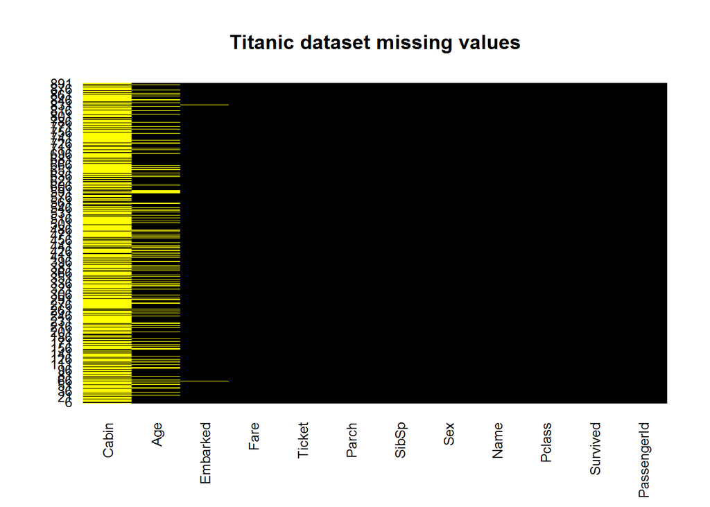

```r
missmap(titanic.data, main = "Titanic dataset missing values",col=c("yellow", "black"), legend=FALSE)
```

Variable Cabin has too many missing values as compare to variable age.We will not use variable Cabin as it has many missing values and other irrelavent variables.

Taking care of missing values by replacing them with the mean of exixting ones.

```r
titanic.data$Age[is.na(titanic.data$Age)]<-mean(titanic.data$Age,na.rm = T)
```

Missing values in Embarked

```r
summary(titanic.data$Embarked)
```

```
##    C    Q    S NA's
##  168   77  644    2
```

Replace missing value with “S”, the most common value.

```r
titanic.data$Embarked[which(is.na(titanic.data$Embarked))] <- 'S'
```

Now dividing the Titanic dataset randomly into two groups, “train” dataset to train the model and “test” dataset to predict values using function sample() in 70:30 ratio.

variables in the training dataset

```r
names(train)
```

```
##  [1] "PassengerId" "Survived"    "Pclass"      "Name"        "Sex"
##  [6] "Age"         "SibSp"       "Parch"       "Ticket"      "Fare"
## [11] "Cabin"       "Embarked"
```

Fitting the model using training dataset

```r
attach(train)
model<-glm(formula=Survived ~ Pclass+Sex+Age+SibSp+Parch+Fare+Embarked,family = binomial(link = "logit"), data = train)
```

Obtaining the results using summary() function

```r
summary(model)
```

```
##
## Call:
## glm(formula = Survived ~ Pclass + Sex + Age + SibSp + Parch +
##     Fare + Embarked, family = binomial(link = "logit"), data = train)
##
## Deviance Residuals:
##     Min       1Q   Median       3Q      Max
## -2.5718  -0.6161  -0.4729   0.6624   2.3211
##
## Coefficients:
##              Estimate Std. Error z value Pr(>|z|)
## (Intercept)  4.269469   0.662055   6.449 1.13e-10 ***
## Pclass      -0.849472   0.167771  -5.063 4.12e-07 ***
## Sexmale     -2.578473   0.228403 -11.289  < 2e-16 ***
## Age         -0.032129   0.009408  -3.415 0.000638 ***
## SibSp       -0.273686   0.121771  -2.248 0.024605 *
## Parch       -0.047259   0.156472  -0.302 0.762632
## Fare         0.004201   0.002985   1.407 0.159317
## EmbarkedQ    0.066149   0.452182   0.146 0.883693
## EmbarkedS   -0.354352   0.284197  -1.247 0.212452
## ---
## Signif. codes:  0 '***' 0.001 '**' 0.01 '*' 0.05 '.' 0.1 ' ' 1
##
## (Dispersion parameter for binomial family taken to be 1)
##
##     Null deviance: 831.47  on 622  degrees of freedom
## Residual deviance: 568.46  on 614  degrees of freedom
## AIC: 586.46
##
## Number of Fisher Scoring iterations: 5
```

Interpreting the results

- Variable Parch, Fare and Embarked are not statistically significant.
- For statistically significant variables, Sex has the lowest p-value suggesting a strong association of the sex of the passenger with the probability of having survived.
- The negative coefficient suggests that male passengers are less likely to have survived.
- Significance of Pclass, Sex and Age prove the better chances of survival of women, children and upper class.
- Lesser p-value of SibSp shows that larger families had lesser chances of survival than smaller ones as drowning of one family member effecting the chances of survival of other member.
- The deviance reduced to 263.01(831.47 - 568.46) points on 8(622 - 614) degree of freedom and AIC = 586.46.

Running the anova() function on the model to analyze the table of deviance.

```r
anova(model, test="Chisq")
```

```
## Analysis of Deviance Table
##
## Model: binomial, link: logit
##
## Response: Survived
##
## Terms added sequentially (first to last)
##
##
##          Df Deviance Resid. Df Resid. Dev  Pr(>Chi)
## NULL                       622     831.47
## Pclass    1   60.518       621     770.95 7.289e-15 ***
## Sex       1  179.095       620     591.86 < 2.2e-16 ***
## Age       1   10.689       619     581.17  0.001078 **
## SibSp     1    6.598       618     574.57  0.010209 *
## Parch     1    0.003       617     574.57  0.955034
## Fare      1    3.695       616     570.87  0.054592 .
## Embarked  2    2.418       614     568.46  0.298537
## ---
## Signif. codes:  0 '***' 0.001 '**' 0.01 '*' 0.05 '.' 0.1 ' ' 1
```

The difference between the null deviance and the residual deviance shows how our model is doing against the null model (a model with only the intercept). The wider this gap, the better. Analyzing the table we can see the drop in deviance when adding each variable one at a time. Again, adding Pclass, Sex and Age significantly reduces the residual deviance. The other variables seem to improve the model less even though SibSp has a low p-value. A large p-value here indicates that the model without the variable explains more or less the same amount of variation. Ultimately drop in deviance and the AIC should be significant. The deviance reduced to 263.01(831.47 - 568.46) points on 8(622 - 614) degree of freedom and AIC = 586.46.

Predicting values on test dataset.Setting decision boundary equal to 0.5.If P(y=1|X) > 0.5 then y = 1 otherwise y=0.

```r
fitted.results<-predict(model,newdata=subset(test,select=c(2,3,5,6,7,8,10,12)),type='response')
fitted.results <- ifelse(fitted.results > 0.5,1,0)
```

Calculating the overall accuracy using formula:

Overall Accuracy = (No.of survived accurately predicted as survived + No.of deceased accurately predicted as deceased)/Total no.of passengers

```
## [1] "Accuracy --> 0.813432835820896"
```

To be more accurate, calculatting confussion matrix using *caret* package to find overall accuracy.

```r
confusionMatrix(tab)
```

```
## Confusion Matrix and Statistics
##
##       predicted
## Actual   0   1
##      0 144  23
##      1  27  74
##
##                Accuracy : 0.8134
##                  95% CI : (0.7615, 0.8582)
##     No Information Rate : 0.6381
##     P-Value [Acc > NIR] : 2.596e-10
##
##                   Kappa : 0.5996
##  Mcnemar's Test P-Value : 0.6714
##
##             Sensitivity : 0.8421
##             Specificity : 0.7629
##          Pos Pred Value : 0.8623
##          Neg Pred Value : 0.7327
##              Prevalence : 0.6381
##          Detection Rate : 0.5373
##    Detection Prevalence : 0.6231
##       Balanced Accuracy : 0.8025
##
##        'Positive' Class : 0
##
```

Plotting ROC curve and finding the AUC (area under the curve).

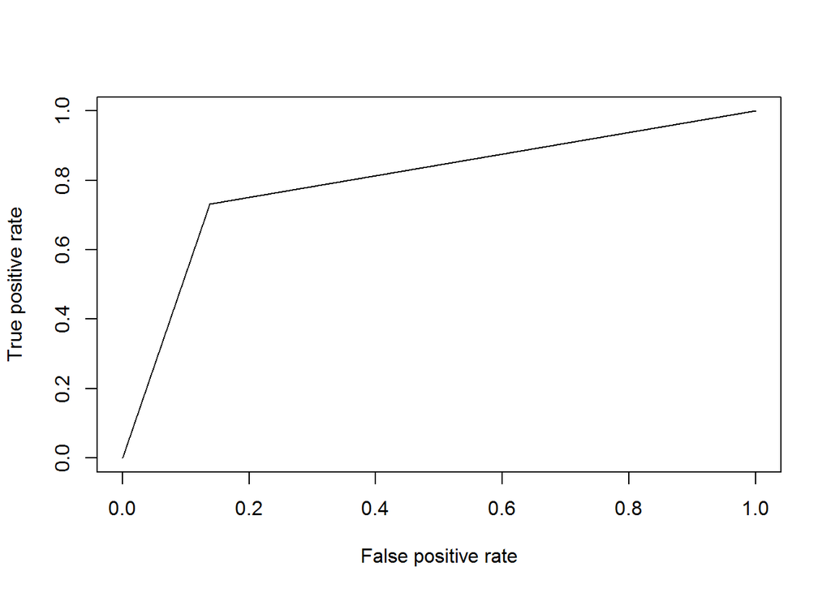

```r
auc
```

```
## [1] 0.7974744
```